# Assignment 6: Visualization - Aesthetic Mapping

*How to do it?*:

- Open the Rmarkdown file of this assignment (link) in Rstudio.
- Right under each **question**, insert a code chunk (you can use the hotkey `Ctrl + Alt + I` to add a code chunk) and code the solution for the question.
- `Knit` the rmarkdown file (hotkey: `Ctrl + Alt + K`) to export an html.
- Publish the html file to your Githiub Page.

*Submission*: Submit the link on Github of the assignment to Canvas.

### Questions on Your Selected Data

Choose a dataset and produce the following types of plots and comment on each plot. Plots should be meaningful. If you use the data we used in class, make sure the plots are not the same as the ones in the slides.

```r
library(tidyverse)
```

```r
library(ggplot2)
df <- read_csv("C:\\Users\\student\\Downloads\\kc_house_data.csv")
```

```r
str(df)
```

```
## spc_tbl_ [21,613 × 21] (S3: spec_tbl_df/tbl_df/tbl/data.frame)
##  $ id           : chr [1:21613] "7129300520" "6414100192" "5631500400" "2487200875" ...
##  $ date         : POSIXct[1:21613], format: "2014-10-13" "2014-12-09" ...
##  $ price        : num [1:21613] 221900 538000 180000 604000 510000 ...
##  $ bedrooms     : num [1:21613] 3 3 2 4 3 4 3 3 3 3 ...
##  $ bathrooms    : num [1:21613] 1 2.25 1 3 2 4.5 2.25 1.5 1 2.5 ...
##  $ sqft_living  : num [1:21613] 1180 2570 770 1960 1680 ...
##  $ sqft_lot     : num [1:21613] 5650 7242 10000 5000 8080 ...
##  $ floors       : num [1:21613] 1 2 1 1 1 1 2 1 1 2 ...
##  $ waterfront   : num [1:21613] 0 0 0 0 0 0 0 0 0 0 ...
##  $ view         : num [1:21613] 0 0 0 0 0 0 0 0 0 0 ...
##  $ condition    : num [1:21613] 3 3 3 5 3 3 3 3 3 3 ...
##  $ grade        : num [1:21613] 7 7 6 7 8 11 7 7 7 7 ...
##  $ sqft_above   : num [1:21613] 1180 2170 770 1050 1680 ...
##  $ sqft_basement: num [1:21613] 0 400 0 910 0 1530 0 0 730 0 ...
##  $ yr_built     : num [1:21613] 1955 1951 1933 1965 1987 ...
##  $ yr_renovated : num [1:21613] 0 1991 0 0 0 ...
##  $ zipcode      : num [1:21613] 98178 98125 98028 98136 98074 ...
##  $ lat          : num [1:21613] 47.5 47.7 47.7 47.5 47.6 ...
##  $ long         : num [1:21613] -122 -122 -122 -122 -122 ...
##  $ sqft_living15: num [1:21613] 1340 1690 2720 1360 1800 ...
##  $ sqft_lot15   : num [1:21613] 5650 7639 8062 5000 7503 ...
##  - attr(*, "spec")=
##   .. cols(
##   ..   id = col_character(),
##   ..   date = col_datetime(format = ""),
##   ..   price = col_double(),
##   ..   bedrooms = col_double(),
##   ..   bathrooms = col_double(),
##   ..   sqft_living = col_double(),
##   ..   sqft_lot = col_double(),
##   ..   floors = col_double(),
##   ..   waterfront = col_double(),
##   ..   view = col_double(),
##   ..   condition = col_double(),
##   ..   grade = col_double(),
##   ..   sqft_above = col_double(),
##   ..   sqft_basement = col_double(),
##   ..   yr_built = col_double(),
##   ..   yr_renovated = col_double(),
##   ..   zipcode = col_double(),
##   ..   lat = col_double(),
##   ..   long = col_double(),
##   ..   sqft_living15 = col_double(),
##   ..   sqft_lot15 = col_double()
##   .. )
##  - attr(*, "problems")=<externalptr>
```

```r
# Changing the `waterfront` variable to be categorical and assigning it categories.
df <- df |>
  mutate(waterfront = if_else(waterfront == 1, "Waterfront", "No Waterfront"))

# Changing `condition`, `view`, and `grade` to be categorical
df$condition <- as.character(df$condition)
df$view <- as.character(df$view)
df$grade <- as.character(df$grade)
```

```r
str(df)
```

```
## tibble [21,613 × 21] (S3: tbl_df/tbl/data.frame)
##  $ id           : chr [1:21613] "7129300520" "6414100192" "5631500400" "2487200875" ...
##  $ date         : POSIXct[1:21613], format: "2014-10-13" "2014-12-09" ...
##  $ price        : num [1:21613] 221900 538000 180000 604000 510000 ...
##  $ bedrooms     : num [1:21613] 3 3 2 4 3 4 3 3 3 3 ...
##  $ bathrooms    : num [1:21613] 1 2.25 1 3 2 4.5 2.25 1.5 1 2.5 ...
##  $ sqft_living  : num [1:21613] 1180 2570 770 1960 1680 ...
##  $ sqft_lot     : num [1:21613] 5650 7242 10000 5000 8080 ...
##  $ floors       : num [1:21613] 1 2 1 1 1 1 2 1 1 2 ...
##  $ waterfront   : chr [1:21613] "No Waterfront" "No Waterfront" "No Waterfront" "No Waterfront" ...
##  $ view         : chr [1:21613] "0" "0" "0" "0" ...
##  $ condition    : chr [1:21613] "3" "3" "3" "5" ...
##  $ grade        : chr [1:21613] "7" "7" "6" "7" ...
##  $ sqft_above   : num [1:21613] 1180 2170 770 1050 1680 ...
##  $ sqft_basement: num [1:21613] 0 400 0 910 0 1530 0 0 730 0 ...
##  $ yr_built     : num [1:21613] 1955 1951 1933 1965 1987 ...
##  $ yr_renovated : num [1:21613] 0 1991 0 0 0 ...
##  $ zipcode      : num [1:21613] 98178 98125 98028 98136 98074 ...
##  $ lat          : num [1:21613] 47.5 47.7 47.7 47.5 47.6 ...
##  $ long         : num [1:21613] -122 -122 -122 -122 -122 ...
##  $ sqft_living15: num [1:21613] 1340 1690 2720 1360 1800 ...
##  $ sqft_lot15   : num [1:21613] 5650 7639 8062 5000 7503 ...
```

1. For one continuous variable:
- Density
- Histogram
- Boxplot

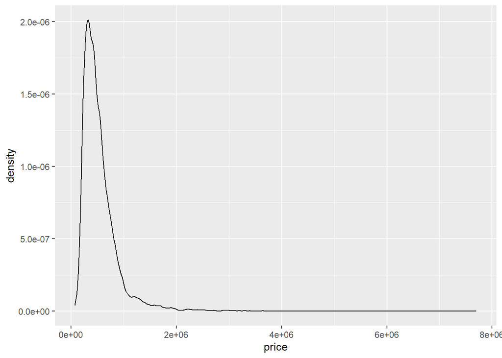

```r
# Density Plot
df |> ggplot() + geom_density(mapping = aes(x = price))
```

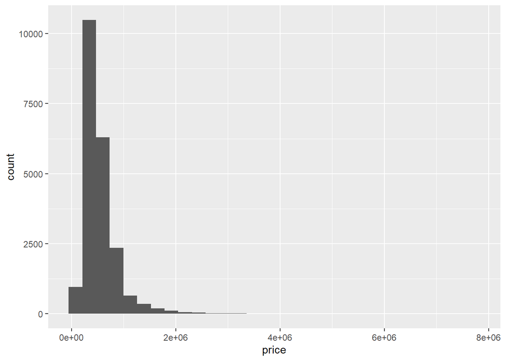

```r
# Histogram
df |> ggplot() + geom_histogram(mapping = aes(x = price))
```

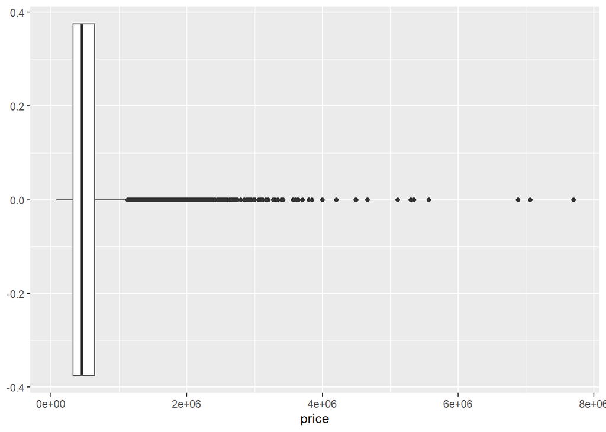

```r
# Boxplot
df |> ggplot() + geom_boxplot(mapping = aes(x =  price))
```

2. For one categorical variable
- Barplot

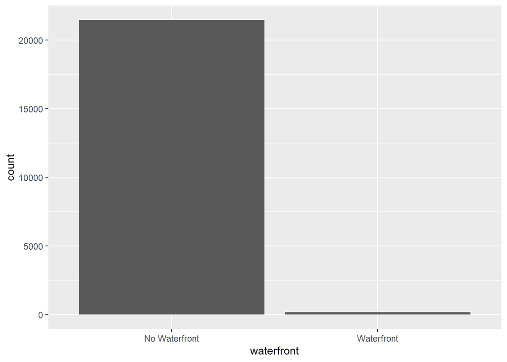

```r
# Barplot
df |> ggplot() + geom_bar(mapping = aes(x = waterfront))
```

3. For two continuous variables
- Scatter Plot
- Line Plot
- Smooth Plot

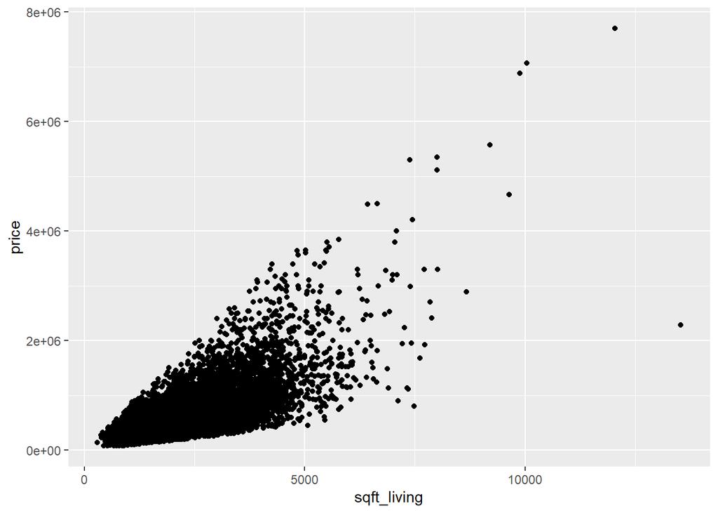

```r
# Scatter Plot
df |> ggplot() + geom_point(mapping = aes(x = sqft_living, y = price))
```

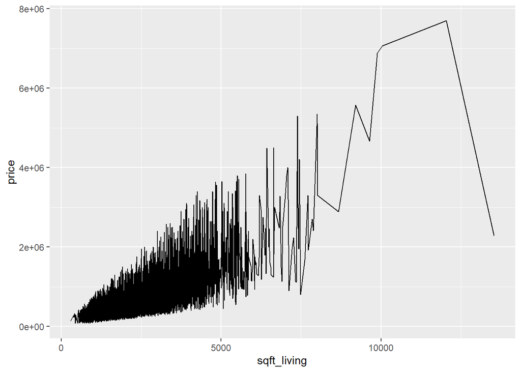

```r
# Line Plot
df |> ggplot() + geom_line(mapping = aes(x = sqft_living, y = price))
```

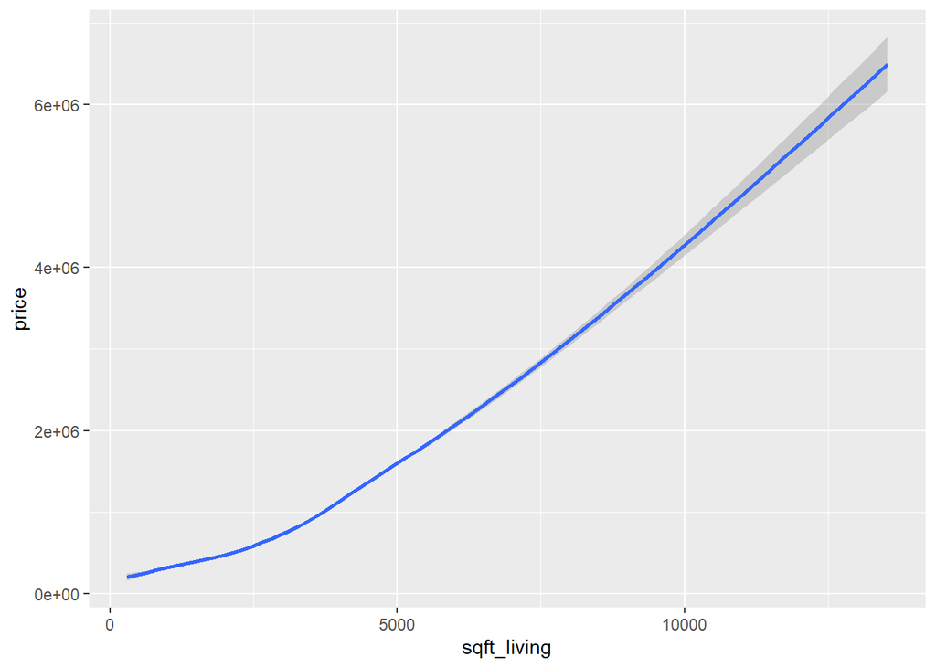

```r
# Smooth Plot
df |> ggplot() + geom_smooth(aes(x = sqft_living, y = price))
```

4. For one continuous + one categorical variables
- Density
- BoxPlot

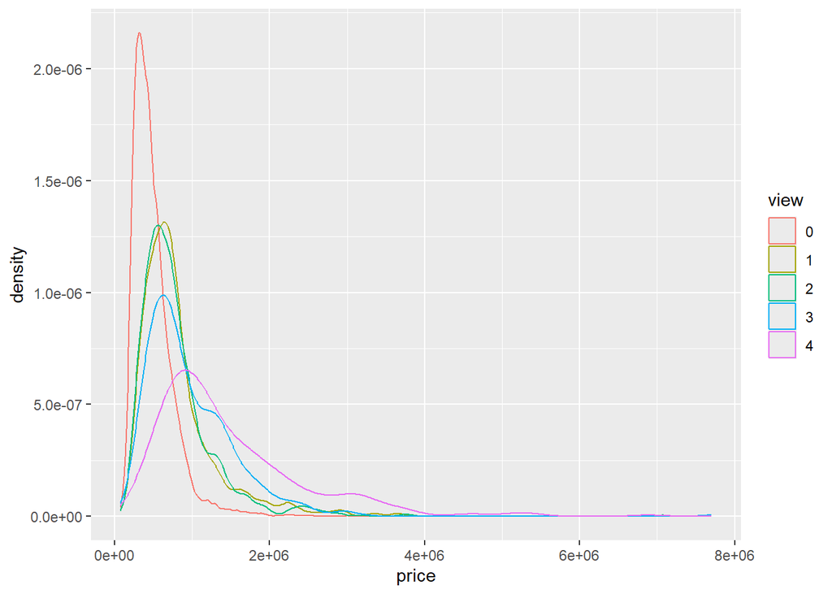

```r
# Density Plot
df |> ggplot() + geom_density(mapping = aes(x = price, color = view))
```

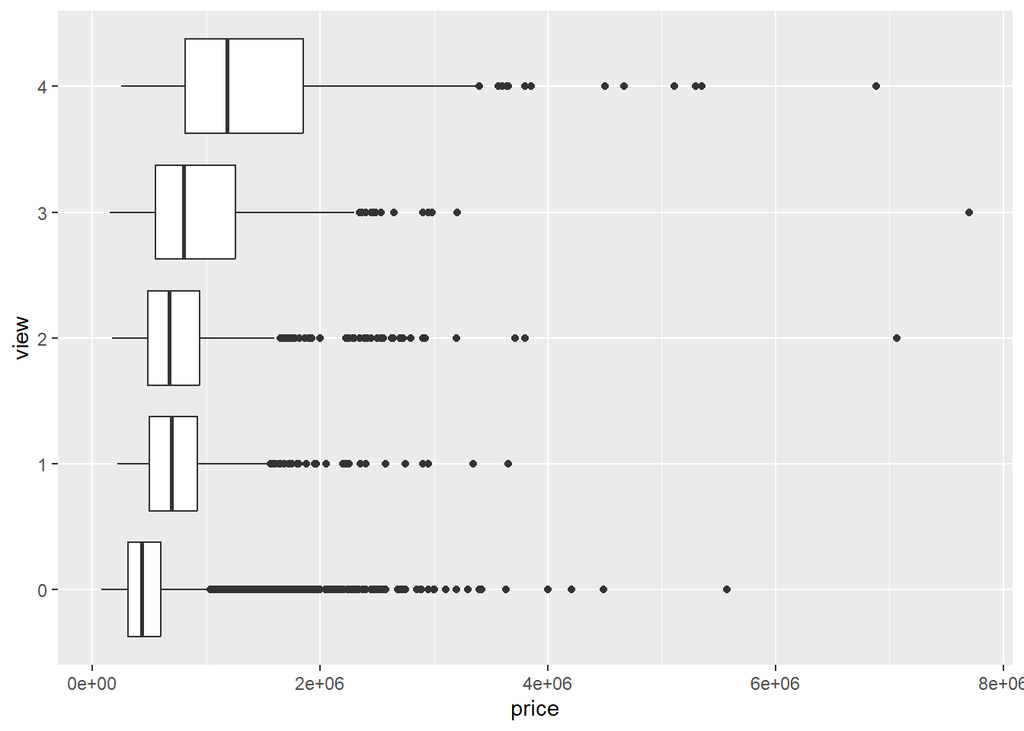

```r
# BoxPlot
df |> ggplot() + geom_boxplot(mapping = aes(x = price, y = view))
```

5. For two categorical variables: barplot

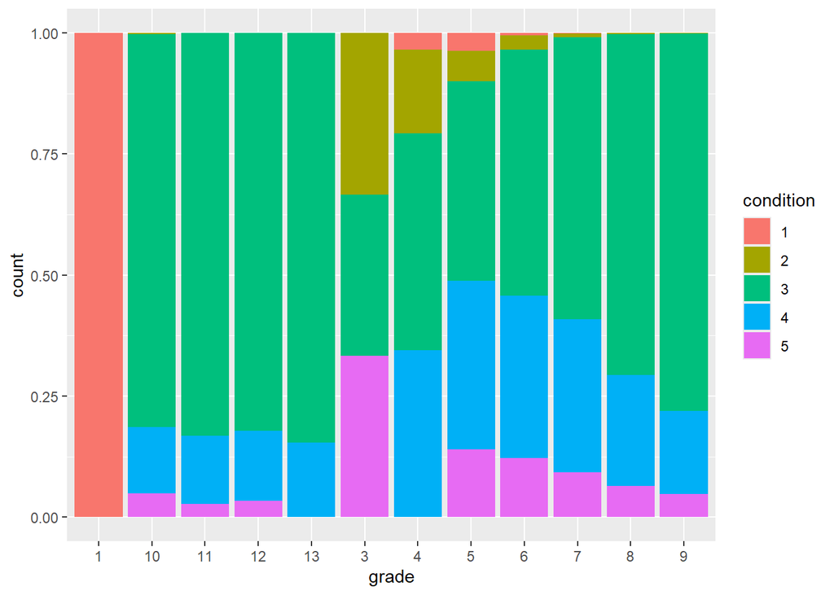

```r
# 2 Categorical Variables Barplot:
df |> ggplot() + geom_bar(mapping=aes(x=grade, fill=condition), position = 'fill')
```

6. A plot that contains three variables

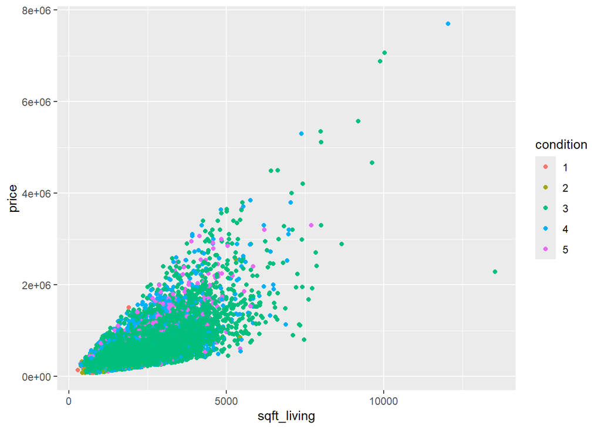

```r
# Three variable plot
df |>  ggplot() + geom_point(aes(x = sqft_living, y = price, color = condition))
```